# In-utero and infancy factors and thyroid cancer risk in adult women in the Sister Study cohort

Published

This version: January 03, 2024

```r
#Time the code running process
start_time <- Sys.time()
```

```r
###Necessary R library and data loading
library(here)
library(tidyverse)
library(gtsummary)
library(survival)
library(cmprsk)
library(broom)
library(broom.helpers)
library(tidymodels)
library(purrr)
library(splines)
library(Gmisc, quietly = TRUE)
library(glue)
library(htmlTable)
library(grid)
library(magrittr)
library(gt)


directory="C:/Users/trant4/OneDrive - National Institutes of Health/Trinh/Postdoc NCI - Risk factors and thyroid cancer/SS"

source(paste(directory,'/Early-life-Thyroid-cancer-SS/analysis/R_created_functions.R',sep = ""),local = knitr::knit_global())
```

```r
earlylife_popu =
  read.csv(paste(directory,"/data/ss_earlylife_popu.csv",sep = ""),
    #because quarto cannot knit the output document if here::here("data/ss_earlylife_popu.csv") is put inside read.csv like this,
    header = TRUE,
    stringsAsFactors = TRUE,
    fileEncoding = "latin1"
  )

earlylife_popu=earlylife_popu|>
  mutate(ident_DTC_PTC=ifelse(ident_DTC_histo=="2) PTC",1,0),
         ident_DTC_stageI=ifelse(ident_DTC_stage_AJCC7=="2) I",1,ident_DTC),
         ident_DTC_adv_stage=ifelse(ident_DTC_stage_AJCC7=="2) I",0,ident_DTC),
         ident_DTC_1cm=ifelse(ident_DTC_size=="2) <1 cm",1,ident_DTC),
         ident_DTC_large_tumor=ifelse(ident_DTC_size=="2) <1 cm",0,ident_DTC))

levels(earlylife_popu$ui_birth_weight_cat)=c("2) Between 2500 and 3999 g","1) < 2500 g","3) 4000+ g","Unknown")

smok=c("sm_age_start_smok_cat","sm_age_start_smok_cont")
```

```r
###Create functions that I'll use in the codes in Early life project

#1. Function for descriptive info
descript_table = function(var_name, var_label,data)
{
  Descriptive_table = data[,-1]   |>
    tbl_summary(
      include = var_name,
      type = all_continuous() ~ "continuous",
      statistic = list(
        all_continuous()
        ~ c("{median} ({p25}, {p75})"),
        all_categorical() ~ "{n} ({p}%)"
      ),
      label = var_label,
      digits = all_continuous() ~ 1,
      missing = "ifany"
    )  |>
    remove_row_type(variables = ses_race,
                    type = "level",
                    level_value = "Unknown")  |>
    remove_row_type(
      variables = ses_race_detail,
      type = "level",
      level_value = c("1) Non-Hispanic White",
                      "2) Non-Hispanic Black",
                      "3) Hispanic")
    )  |>
    remove_row_type(variables = ses_race_detail,
                    type = "header")
  return(Descriptive_table)
}

#2. Function for cox models
cox_model = function(surv, var_name, var_label, covar, data, model_name=NULL)
{
  results_cox_function = map2(
    .x = var_name,
    .y = var_label,
    ~ #add a condition to not adjust for baseline smoking status if the variables of interest are "Age started smoking"
      (if (.x %in% smok) {
        reformulate(c(.x, covar[!covar == "smok_status"]), response = surv)
      } else {
        reformulate(c(.x, covar), response = surv)
      }) |>
      coxph(method = "breslow", data = data) |>
      tbl_regression(
        exponentiate = TRUE,
        conf.int = TRUE,
        conf.level = 0.95,
        add_estimate_to_reference_rows = TRUE,
        label = .y,
        include = .x
      ) |>
      modify_fmt_fun(estimate ~ function(x)
        ifelse(is.na(x), NA, "—"),
        rows = n_event == "0") |>
      modify_fmt_fun(ci ~ function(x)
        ifelse(is.na(x), NA, "—"),
        rows = n_event == "0")

  ) |>
    tbl_stack() |>
    modify_column_hide(p.value) |>
    modify_table_styling(
      columns = c(estimate, ci),
      rows = p.value < 0.05,
      text_format = "bold"
    ) |>
    modify_header(n_event ~ "**Number of events**",
                  exposure ~ "**Person-years**",
                  estimate ~ "**HR**") |>
    modify_table_body(~ .x |> dplyr::relocate(exposure, .before = estimate))

  if (!is.null(model_name)) {
    results_cox_function = results_cox_function |>   modify_spanning_header(c(n_event, exposure, estimate, ci) ~
                                                                              paste0("**", model_name, "**"))
  }
  return(results_cox_function)
  rm(results_cox_function)
}


#3 Stratified analyses (wide)


stratification_wide = function(strat_var,
                          surv,
                          var_name,
                          var_label,
                          covar,
                          data)
{
  data = data |>
    filter({{strat_var}}!="Unknown")|>droplevels()

  # Extract unique levels from the stratification variable
  unique_levels = data |> select({{strat_var}}) |>
    summarise_each(list( ~ levels(.))) |>
    pull() |> as.factor()


  header = substring(unique_levels,4)
  header = paste("**", header, "**",sep="")


  # Use purrr::map to create a list of stratified data frames and appy the function cox_model on them
  results = unique_levels |>
    map(
      ~ data |>
        filter({{strat_var}} == .x) |>
        cox_model(surv = surv,
                  var_name = var_name,
                  var_label = var_label,
                  covar = covar
        )
    ) |>
    tbl_merge(tab_spanner = header)
  return(results)
  rm(results)
}

#4 Stratified analyses (long)


stratification_long = function(strat_var,
                               surv,
                               var_name,
                               var_label,
                               covar,
                               data)
{
  data = data |>
    filter({{strat_var}}!="Unknown")|>droplevels()

  # Extract unique levels from the stratification variable
  unique_levels = data |> select({{strat_var}}) |>
    summarise_each(list( ~ levels(.))) |>
    pull() |> as.factor()


  header = substring(unique_levels,4)
  header = paste("**", header, "**",sep="")


  # Use purrr::map to create a list of stratified data frames and appy the function cox_model on them
  results = unique_levels |>
    map(
      ~ data |>
        filter({{strat_var}} == .x) |>
        cox_model(surv = surv,
                  var_name = var_name,
                  var_label = var_label,
                  covar = covar
        )) |>
    tbl_stack()|>modify_table_body(~ .x |> dplyr::mutate(label = unique_levels))
  return(results)
  rm(results)
}

#5. Function for competing risk models

competing_risk_model = function(surv, var_name, var_label, covar, data, model_name = NULL)
{
  competing = function(x, y)
  {
    formula = reformulate(c(x, covar), response = "Surv(fgstart, fgstop, fgstatus)")
    finegray_data = reformulate(c(x, covar), response = surv) |>
      finegray(id = PSID, data = data)
    fine_gray = coxph(formula, weight = fgwt, finegray_data) |>
      tbl_regression(
        exponentiate = TRUE,
        conf.int = TRUE,
        conf.level = 0.95,
        add_estimate_to_reference_rows = TRUE,
        label = y,
        include = x
      )|>
      modify_fmt_fun(estimate ~ function(x)
        ifelse(is.na(x), NA, "—"),
        rows = n_event == "0") |>
      modify_fmt_fun(ci ~ function(x)
        ifelse(is.na(x), NA, "—"),
        rows = n_event == "0")
  }

  results_competing_risk_function <-
    map2(.x = var_name, .y = var_label, competing) |>
    tbl_stack() |>
    modify_column_hide(p.value) |>
    modify_table_styling(
      columns = c(estimate, ci),
      rows = p.value < 0.05,
      text_format = "bold"
    ) |>
    modify_header(n_event ~ "**Number of events**",
                  exposure ~ "**Person-years**",
                  estimate ~ "**HR**") |>
    modify_table_body(~ .x |> dplyr::relocate(exposure, .before = estimate))

  if (!is.null(model_name)) {
    results_competing_risk_function = results_competing_risk_function |>   modify_spanning_header(c(n_event, exposure, estimate, ci) ~
                                                                              paste0("**", model_name, "**"))
  }
  return(results_competing_risk_function)
  rm(results_competing_risk_function)
}

#6. function to sort ui_birth_weight properly
sort_birth_weight = function(table) {table|>
  modify_table_body( ~.x |>
                       dplyr::mutate(sort = 1:nrow(.x)) |>
                       dplyr::mutate(sort = if_else(label == "2) Between 2500 and 3999 g",
                                                    sort + 1,
                                                    if_else(label =="1) < 2500 g", sort - 1, sort)
                       )) |> arrange(sort))
}
#7 function to sort properly rep_br_dev_age_cat, rep_age_menarche_cat, an_weight_age10, an_height_age10, an_weight_teen, ses_income_child
sort_childhood = function(table) {table|>
    modify_table_body( ~.x |>
                         dplyr::mutate(sort = 1:nrow(.x)) |>
                         dplyr::mutate(sort = if_else(label == "2) 11-13 years of age",  sort + 1,
                                                      if_else(label =="1) Less than 11 years of age", sort - 1, sort)))|>
                         dplyr::mutate(sort = if_else(label == "2) 12-14 years of age",  sort + 1,
                                                      if_else(label =="1) Less than 12 years of age", sort - 1, sort)))|>
                         dplyr::mutate(sort = if_else(label == "2) Same weight",  sort + 1,
                                                      if_else(label =="1) Lighter", sort - 1, sort)))|>
                         dplyr::mutate(sort = if_else(label == "2) Same height",  sort + 1,
                                                      if_else(label =="1) Shorter", sort - 1, sort)))|>
                         dplyr::mutate(sort = if_else(label == "2) Middle income",  sort + 1,
                                                      if_else(label =="1) Well off", sort - 1, sort))) |> arrange(sort))
}

#8 Polish tables for in utero paper
polish_utero = function(data, group_name = FALSE)
{
  #polish the table
  if (group_name==TRUE)
  {
  data = data |>
    modify_table_body(
      ~ .x  |>
        dplyr::add_row(
          label = "Maternal pregnancy characteristics",
          .before = grep("ui_diab_all_mother", data$table_body$variable)
        )  |>
        dplyr::add_row(
          label = "Paternal pregnancy characteristics",
          .before = grep("ui_diab_father", data$table_body$variable) + 1
        )  |>
        dplyr::add_row(
          label = "Birth and infancy characteristics",
          .before = grep("ui_birth_weight_cat", data$table_body$variable) + 2
        )
    )

  data = data |>
    modify_table_styling(
      column = "label",
      rows = data$table_body$label %in% c(
        "Participant characteristics at baseline",
        "Maternal pregnancy characteristics",
        "Paternal pregnancy characteristics",
        "Birth and infancy characteristics"
      ),
      text_format = "bold"
    )
  }
  data = modify_footnote(data,
                         abbreviation = TRUE)|>
    as_gt() |> tab_footnote(footnote = "Multivariate models were adjusted for self-identified race/ethnicity, baseline BMI, smoking status,
                            personal history of benign thyroid disease, educational level, household annual income, and Area Deprivation Index")
  return(data)
}

#9 Polish tables for childhood paper
polish_childhood = function(data, group_name = FALSE)
{
  #polish the table
  if (group_name==TRUE)
  {
    data = data |>
    modify_table_body(
      ~ .x  |>
        dplyr::add_row(
          label = "Growth and reproductive factors",
          .before = grep("an_weight_age10", data$table_body$variable)
        )  |>
        dplyr::add_row(
          label = "Lifestyle factors",
          .before = grep("ph_hrs_wk_before20_cat", data$table_body$variable) + 1
        )  |>
        dplyr::add_row(
          label = "Socioeconomic factors",
          .before = grep("ses_income_child", data$table_body$variable) + 2
        )
    )

  data = data |>
    modify_table_styling(
      column = "label",
      rows = data$table_body$label %in% c(
        "Participant characteristics at baseline",
        "Growth and reproductive factors",
        "Lifestyle factors",
        "Socioeconomic factors"
      ),
      text_format = "bold"
    )
  }
  data = modify_footnote(data, abbreviation = TRUE) |>
    as_gt() |> tab_footnote(
      footnote = "Multivariate models were adjusted for self-identified race/ethnicity, baseline BMI, smoking status
                         (except for the analysis for the age started smoking), personal history of benign thyroid disease, educational level,
                         household annual income, and Area Deprivation Index"
    )

}
```

```r
###Create lists of exposure and covariates to avoid repetition in the code

#Covariates to adjust in Cox models
covariates_label_utero = list(
  "ses_race"~"Race",
  "an_bmi_cat"~"BMI",
  "smok_status"~"Smoking status",
  "illness_thyroid_all"~"Benign thyroid disease",
  "ses_edu_level"~"Educational level",
  "ses_income"~"Household annual income",
  "ses_ADI_baseline_cat"~"Area depreviation index"
)
covariates_utero = substr(covariates_label_utero, 2, unlist(gregexpr("~", covariates_label_utero)) - 3)

#In-utero and infancy factors
var_label_utero = list(
  "ui_diab_all_mother"~"Pre-pregnancy or gestational diabetes",
  "ui_hypertension_all"~"Gestational hypertension or hypertension-related disorders",
###"ui_epilepsy_prior"~"Epilepsy",                                            #not included because of number of cases<5
  "ui_vomit"~"Morning sickness with vomiting",
###"ui_DES"~"DES use",                                                        #not included because of number of cases<5
  "ui_mother_smok"~"Smoking during pregnancy",
  "ui_hh_smok"~"Household secondhand smoking during pregnancy",
  "ui_mother_age_cat"~"Age at delivery",
  "ui_mother_age_cont"~"Age at delivery (year, continuous)",
  "ui_diab_father"~"Diabetes",
  "ui_father_smok"~"Smoking during 3 months before conception",
  "ui_father_age_cat"~"Age at delivery",
  "ui_father_age_cont"~"Age at delivery (year, continuous)",
  "ui_birth_weight_cat"~"Birth weight",
  "ui_birth_weight_cont"~"Birth weight (continuous)",
  "ui_maternal_1st_born"~"First born",
  "ui_preg_order_cat"~"Birth order",
  "ui_preg_order_cont"~"Birth order (continuous)",
  "ui_preg_last_cat"~"Time since last pregnancy of the participants' mother",
  "ui_preg_last_cont"~"Time since last pregnancy of the participants' mother (year, continuous)",
  "ui_multiple_birth"~"Multiple birth",
  "ui_early_gest"~"Gestational age at birth",
###"ui_early_gest_detail"~"Gestational age at birth",                         #for exploratory purposes only, number of cases<5
  "ui_breastfed"~"Ever breastfed"
###"ui_soy"~"Ever fed soy formula"                                            #not included because of number of cases<5)
)
var_name_utero = substr(var_label_utero, 2, unlist(gregexpr("~", var_label_utero)) - 3)
```

# 1 Main Tables and Figures

## 1.1 Figure 1: Flowchart of study population

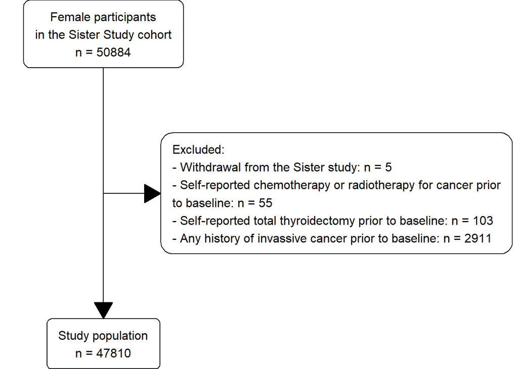

```r
eligible <- boxGrob(glue("Female participants", "in the Sister Study cohort",
                         "n = 50884",
                         pop = txtInt(1032),
                         .sep = "\n"),y = unit(0.5, "npc"),
  x = unit(0.2, "npc"))
included <- boxGrob(glue("Study population",
                         "n = 47810",
                         incl = txtInt(122),
                         .sep = "\n"),y = unit(0.5, "npc"),
  x = unit(0.2, "npc"))

excluded <- boxGrob(glue("Excluded:",
                         " - Withdrawal from the Sister study: n = 5",
                         " - Self-reported chemotherapy or radiotherapy for cancer prior",
                         " to baseline: n = 55",
                         " - Self-reported total thyroidectomy prior to baseline: n = 103",
                         " - Any history of invassive cancer prior to baseline: n = 2911",
                         tot = 30,
                         uninterested = 12,
                         contra = 30 - 12,
                         .sep = "\n"),
                    just = "left")

grid.newpage()
vert <- spreadVertical(eligible = eligible,
                       included = included)

excluded <- moveBox(excluded,
                    x = 0.65,
                    y =coords(vert$included)$top + distance(vert$eligible, vert$included, half = TRUE, center = FALSE))

for (i in 1:(length(vert) - 1)) {
  connectGrob(vert[[i]], vert[[i + 1]], type = "vert") %>%
    print
}

connectGrob(vert$eligible, excluded, type = "L")

# Print boxes
print(vert)
print(excluded)
```

```r
rm(eligible,excluded,included,vert)
```

## 1.2 Table 1: Characteristics of the study population (n=47810)

```r
table1_descript_var_label = list(
  "ident_ageexact_bl"~"Age at baseline",
  "ses_race"~"Race",
  "an_bmi_cat"~"BMI",
  "smok_status"~"Smoking status",
  "illness_thyroid_all"~"Benign thyroid disease",
  "ses_edu_level"~"Educational level",
  "ses_income"~"Household annual income",
  "ses_ADI_baseline_cat"~"Area depreviation index"
)
table1_descript_var_name = substr(table1_descript_var_label, 2, unlist(gregexpr("~", table1_descript_var_label)) - 3)

descript_covar = descript_table(var_name = table1_descript_var_name,
                                var_label = table1_descript_var_label,
                                data = earlylife_popu) |> sort_birth_weight()
rm(table1_descript_var_label,table1_descript_var_name)
descript_covar
```

Table 1: Characteristics of the study population (n=47810)

| **Characteristic** | **N = 47,810**<sup>1</sup> |
| --- | --- |
| Age at baseline | 55.4 (48.9, 62.1) |
| Race |  |
| 1) Non-Hispanic White | 39,863 (83%) |
| 2) Non-Hispanic Black | 4,297 (9.0%) |
| 3) Hispanic | 2,409 (5.0%) |
| 4) Non-Hispanic all other races | 1,227 (2.6%) |
| BMI |  |
| 1) <25 | 18,307 (38%) |
| 2) 25.0-29.9 | 15,172 (32%) |
| 3) 30.0+ | 14,315 (30%) |
| Unknown | 16 (<0.1%) |
| Smoking status |  |
| 1) Never smoked | 27,054 (57%) |
| 2) Past smoker | 16,876 (35%) |
| 3) Current smoker | 3,864 (8.1%) |
| Unknown | 16 (<0.1%) |
| Benign thyroid disease |  |
| 1) No | 37,180 (78%) |
| 2) Yes | 10,630 (22%) |
| Educational level |  |
| 1) Highschool or GED or less | 7,268 (15%) |
| 2) Some college or associate or technical degree | 16,122 (34%) |
| 3) Bachelors degree or higher | 24,408 (51%) |
| Unknown | 12 (<0.1%) |
| Household annual income |  |
| 1) <$50000 | 12,191 (25%) |
| 2) $50000-$99999 | 19,511 (41%) |
| 3) $100000+ | 16,108 (34%) |
| Area depreviation index |  |
| 1) Less than 30 1 | 23,444 (49%) |
| 2) 30 or more | 23,146 (48%) |
| Unknown | 1,220 (2.6%) |

<sup>1</sup> Median (IQR); n (%)

## 1.3 Table 2: Association between in-utero and infancy factors and thyroid cancer incidence in the Sister Study participants

```r
###To create Table Association between in-utero and infancy factors and thyroid cancer incidence

####Loop over in utero and infancy factors in cox models, both univariate and multivariate analyses
descript_utero = descript_table(var_name = var_name_utero,
                                var_label = var_label_utero,
                                data = earlylife_popu)|> sort_birth_weight()

univariate_utero=cox_model(surv = "Surv(ident_ageexact_bl, ident_EOF, ident_DTC)",
                     var_name = var_name_utero,
                     var_label = var_label_utero,
                     covar = NULL,
                     data=earlylife_popu)|> sort_birth_weight()

multivariate_utero=cox_model(surv = "Surv(ident_ageexact_bl, ident_EOF, ident_DTC)",
                       var_name = var_name_utero,
                       var_label = var_label_utero,
                       covar = covariates_utero,
                       data=earlylife_popu)|> sort_birth_weight()

#assemble descriptive table and cox models' results
cox_utero = tbl_merge(
  tbls = list(descript_utero, univariate_utero, multivariate_utero),
  tab_spanner = c("**N (%)**",
                  "**Univariate models**",
                  "**Multivariate models**")) |>
  modify_column_hide(c(n_event_3,exposure_3))|>polish_utero(group_name = TRUE)
```

```r
#return the table
rm(descript_utero, univariate_utero, multivariate_utero)
cox_utero
```

Table 2: Association between in-utero and infancy factors and thyroid cancer incidence

| **Characteristic** | **N (%)** **N = 47,810**<sup>1</sup> | **Univariate models** **Number of events** | **Univariate models** **Person-years** | **Univariate models** **HR**<sup>2</sup> | **Univariate models** **95% CI**<sup>2</sup> | **Multivariate models** **HR**<sup>2</sup> | **Multivariate models** **95% CI**<sup>2</sup> |
| --- | --- | --- | --- | --- | --- | --- | --- |
| Maternal pregnancy characteristics |  |  |  |  |  |  |  |
| Pre-pregnancy or gestational diabetes |  |  |  |  |  |  |  |
| 1) Probably not/Definitely not | 45,912 (96%) | 224 | 561,485 | 1.00 | — | 1.00 | — |
| 2) Definitely/Probably | 432 (0.9%) | 5 | 5,198 | 2.35 | 0.97, 5.70 | 2.33 | 0.96, 5.67 |
| Unknown | 1,466 (3.1%) | 4 | 15,217 | 0.65 | 0.24, 1.76 | 0.68 | 0.25, 1.84 |
| Gestational hypertension or hypertension-related disorders |  |  |  |  |  |  |  |
| 1) Probably not/Definitely not | 39,837 (83%) | 195 | 489,036 | 1.00 | — | 1.00 | — |
| 2) Definitely/Probably | 1,630 (3.4%) | 15 | 19,712 | 1.88 | 1.11, 3.18 | 1.87 | 1.10, 3.16 |
| Unknown | 6,343 (13%) | 23 | 73,152 | 0.81 | 0.53, 1.25 | 0.83 | 0.53, 1.28 |
| Morning sickness with vomiting |  |  |  |  |  |  |  |
| 1) Probably not/Definitely not | 12,592 (26%) | 68 | 157,487 | 1.00 | — | 1.00 | — |
| 2) Definitely/Probably | 16,917 (35%) | 92 | 206,623 | 1.05 | 0.77, 1.44 | 1.05 | 0.76, 1.44 |
| Unknown | 18,301 (38%) | 73 | 217,790 | 0.82 | 0.58, 1.15 | 0.82 | 0.58, 1.16 |
| Smoking during pregnancy |  |  |  |  |  |  |  |
| 1) Probably not/Definitely not | 30,527 (64%) | 151 | 372,745 | 1.00 | — | 1.00 | — |
| 2) Definitely/Probably | 14,179 (30%) | 69 | 174,155 | 0.97 | 0.73, 1.29 | 0.92 | 0.69, 1.23 |
| Unknown | 3,104 (6.5%) | 13 | 35,000 | 0.93 | 0.53, 1.63 | 0.92 | 0.52, 1.63 |
| Household secondhand smoking during pregnancy |  |  |  |  |  |  |  |
| 1) Probably not/Definitely not | 18,176 (38%) | 103 | 223,838 | 1.00 | — | 1.00 | — |
| 2) Definitely/Probably | 25,370 (53%) | 117 | 309,989 | 0.83 | 0.63, 1.08 | 0.82 | 0.63, 1.07 |
| Unknown | 4,264 (8.9%) | 13 | 48,073 | 0.61 | 0.34, 1.08 | 0.62 | 0.35, 1.12 |
| Age at delivery |  |  |  |  |  |  |  |
| 1) Before 25 years | 13,322 (28%) | 68 | 159,890 | 1.00 | — | 1.00 | — |
| 2) Between 25 and 29 years | 14,165 (30%) | 73 | 174,094 | 0.98 | 0.70, 1.36 | 0.95 | 0.68, 1.32 |
| 3) Between 30 and 34 years | 10,840 (23%) | 48 | 133,670 | 0.83 | 0.57, 1.20 | 0.80 | 0.55, 1.16 |
| 4) 35+ years | 8,527 (18%) | 40 | 104,456 | 0.88 | 0.59, 1.30 | 0.85 | 0.57, 1.26 |
| Unknown | 956 (2.0%) | 4 | 9,790 | 0.92 | 0.34, 2.53 | 0.92 | 0.33, 2.54 |
| Age at delivery (year, continuous) | 28.0 (24.0, 33.0) | 229 | 572,110 | 0.99 | 0.97, 1.01 | 0.99 | 0.97, 1.01 |
| Unknown | 956 |  |  |  |  |  |  |
| Paternal pregnancy characteristics |  |  |  |  |  |  |  |

[output cut: 56 more lines]

Multivariate models were adjusted for self-identified race/ethnicity, baseline BMI, smoking status, personal history of benign thyroid disease, educational level, household annual income, and Area Deprivation Index  
<sup>1</sup> n (%); Median (IQR)  
<sup>2</sup> HR = Hazard Ratio, CI = Confidence Interval

## 1.4 Table 3: Association between birth weight (continuous) and thyroid cancer incidence in the Sister Study participants by Area Deprivation Index, levels of education, and household income

```r
strat_ADI_birthweight = stratification_long(
  strat_var = ses_ADI_baseline_cat,
  surv = "Surv(ident_ageexact_bl, ident_EOF, ident_DTC)",
  var_name = "ui_birth_weight_cont",
  var_label = list("ui_birth_weight_cont" ~ "Birth weight (continuous)"),
  covar = covariates_utero,
  data = earlylife_popu
)

strat_edu_birthweight = stratification_long(
  strat_var = ses_edu_level,
  surv = "Surv(ident_ageexact_bl, ident_EOF, ident_DTC)",
  var_name = "ui_birth_weight_cont",
  var_label = list("ui_birth_weight_cont" ~ "Birth weight (continuous)"),
  covar = covariates_utero,
  data = earlylife_popu
)

strat_income_birthweight = stratification_long(
  strat_var = ses_income,
  surv = "Surv(ident_ageexact_bl, ident_EOF, ident_DTC)",
  var_name = "ui_birth_weight_cont",
  var_label = list("ui_birth_weight_cont" ~ "Birth weight (continuous)"),
  covar = covariates_utero,
  data = earlylife_popu
)


strat_all_birthweight = tbl_stack(list(
  strat_ADI_birthweight,
  strat_edu_birthweight,
  strat_income_birthweight
))

strat_all_birthweight = strat_all_birthweight |> modify_table_body(
  ~ .x  |>
    dplyr::add_row(
      label = "Area Deprivation Index",
      .before = grep("1) Less than 30", strat_all_birthweight$table_body$label)
    )  |>
    dplyr::add_row(
      label = "Level of education",
      .before = grep(
        "1) Highschool or GED or less",
        strat_all_birthweight$table_body$label
      ) + 1
    )  |>
    dplyr::add_row(
      label = "Household income",
      .after = grep(
        "3) Bachelors degree or higher",
        strat_all_birthweight$table_body$label
      ) + 2
    )
) |>
  modify_table_styling(
    column = "label",
    rows = strat_all_birthweight$table_body$label %in% c(
      "Area Deprivation Index",
      "Level of education",
      "Household income"
    ),
    text_format = "bold"
  )

strat_all_birthweight
```

Table 3: Association between birth weight (continuous) and thyroid cancer incidence in the Sister Study participants by Area Deprivation Index, levels of education, and household income

| **Characteristic** | **Number of events** | **Person-years** | **HR**<sup>1</sup> | **95% CI**<sup>1</sup> |
| --- | --- | --- | --- | --- |
| Area Deprivation Index |  |  |  |  |
| 1) Less than 30 1 | 92 | 218,530 | 1.15 | 0.97, 1.35 |
| 2) 30 or more | 66 | 200,669 | 1.10 | 0.91, 1.32 |
| Level of education |  |  |  |  |
| 1) Highschool or GED or less | 18 | 57,860 | 1.51 | 1.08, 2.10 |
| 2) Some college or associate or technical degree | 58 | 139,746 | 1.05 | 0.86, 1.29 |
| 3) Bachelors degree or higher | 91 | 229,196 | 1.11 | 0.94, 1.30 |
| Household income |  |  |  |  |
| 1) <$50000 | 42 | 95,593 | 1.13 | 0.91, 1.42 |
| 2) $50000-$99999 | 68 | 177,627 | 1.10 | 0.91, 1.32 |
| 3) $100000+ | 57 | 153,698 | 1.16 | 0.93, 1.44 |

<sup>1</sup> HR = Hazard Ratio, CI = Confidence Interval

## 1.5 Table 4: Simultaneously adjusted association between thyroid cancer risk and pre-pregnancy or gestational diabetes, gestational hypertension or hypertension-related disorders, birth weight, and gestational age at birth

```r
surv = "Surv(ident_ageexact_bl, ident_EOF, ident_DTC)"
mutual_label_cat = list(
  "ui_diab_all_mother" ~ "Pre-pregnancy or gestational diabetes",
  "ui_hypertension_all" ~ "Gestational hypertension or pre-eclampsia",
  "ui_early_gest" ~ "Gestational age at birth",
  "ui_birth_weight_cat" ~ "Birth weight"
)
mutual_name_cat = substr(mutual_label_cat, 2, unlist(gregexpr("~", mutual_label_cat)) - 3)

mutual_label_cont = list(
  "ui_diab_all_mother" ~ "Pre-pregnancy or gestational diabetes",
  "ui_hypertension_all" ~ "Gestational hypertension or pre-eclampsia",
  "ui_early_gest" ~ "Gestational age at birth",
  "ui_birth_weight_cont" ~ "Birth weight (continuous)"
)
mutual_name_cont = substr(mutual_label_cont, 2, unlist(gregexpr("~", mutual_label_cont)) - 3)

hyper_diab_birthweight_mutual_cat = reformulate(c(mutual_name_cat, covariates_utero), response = surv) |>
  coxph(method = "breslow", data = earlylife_popu) |>
  tbl_regression(
    exponentiate = TRUE,
    conf.int = TRUE,
    conf.level = 0.95,
    add_estimate_to_reference_rows = TRUE,
    label = mutual_label_cat,
    include = mutual_name_cat
  )|> sort_birth_weight()

hyper_diab_birthweight_mutual_cont = reformulate(c(mutual_name_cont, covariates_utero), response = surv) |>
  coxph(method = "breslow", data = earlylife_popu) |>
  tbl_regression(
    exponentiate = TRUE,
    conf.int = TRUE,
    conf.level = 0.95,
    add_estimate_to_reference_rows = TRUE,
    label = list("ui_birth_weight_cont" ~ "Birth weight (continuous)"),
    include = "ui_birth_weight_cont"
  )

hyper_diab_birthweight_mutual_all = tbl_stack(list(
  hyper_diab_birthweight_mutual_cat,
  hyper_diab_birthweight_mutual_cont
)) |>
  modify_fmt_fun(estimate ~ function(x)
    ifelse(is.na(x), NA, "—"),
    rows = n_event == "0") |>
  modify_fmt_fun(ci ~ function(x)
    ifelse(is.na(x), NA, "—"),
    rows = n_event == "0") |>
  modify_column_hide(p.value) |>
  modify_table_styling(
    columns = c(estimate, ci),
    rows = p.value < 0.05,
    text_format = "bold"
  ) |>
  modify_header(n_event ~ "**Number of events**",
                exposure ~ "**Person-years**",
                estimate ~ "**HR**") |>
  modify_table_body( ~ .x |> dplyr::relocate(exposure, .before = estimate))|>
  modify_footnote(abbreviation = TRUE,
                         `estimate` ~ "Multivariate models were adjusted for self-identified race/ethnicity, baseline BMI, smoking status,
                         personal history of benign thyroid disease, educational level, household annual income, and Area Deprivation Index"
  )
hyper_diab_birthweight_mutual_all
```

Table 4: Simultaneously adjusted association between thyroid cancer risk and pre-pregnancy or gestational diabetes, gestational hypertension or hypertension-related disorders, birth weight, and gestational age at birth

| **Characteristic** | **Number of events** | **Person-years** | **HR**<sup>1</sup> | **95% CI**<sup>1</sup> |
| --- | --- | --- | --- | --- |
| Pre-pregnancy or gestational diabetes |  |  |  |  |
| 1) Probably not/Definitely not | 224 | 561,485 | 1.00 | — |
| 2) Definitely/Probably | 5 | 5,198 | 1.90 | 0.77, 4.70 |
| Unknown | 4 | 15,217 | 0.73 | 0.25, 2.13 |
| Gestational hypertension or pre-eclampsia |  |  |  |  |
| 1) Probably not/Definitely not | 195 | 489,036 | 1.00 | — |
| 2) Definitely/Probably | 15 | 19,712 | 1.89 | 1.11, 3.23 |
| Unknown | 23 | 73,152 | 0.88 | 0.55, 1.42 |
| Gestational age at birth |  |  |  |  |
| 1) Born post-term or up to 2 weeks pre-term | 115 | 236,623 | 1.00 | — |
| 2) Born at least 2 weeks before the due date | 6 | 34,686 | 0.42 | 0.18, 0.99 |
| Unknown | 112 | 310,592 | 0.78 | 0.59, 1.04 |
| Birth weight |  |  |  |  |
| 1) < 2500 g | 8 | 42,853 | 0.61 | 0.29, 1.27 |
| 2) Between 2500 and 3999 g | 137 | 349,209 | 1.00 | — |
| 3) 4000+ g | 23 | 38,571 | 1.44 | 0.92, 2.25 |
| Unknown | 65 | 151,267 | 1.27 | 0.93, 1.73 |
| Birth weight (continuous) | 167 | 426,919 | 1.06 | 0.93, 1.20 |

<sup>1</sup> Multivariate models were adjusted for self-identified race/ethnicity, baseline BMI, smoking status, personal history of benign thyroid disease, educational level, household annual income, and Area Deprivation Index, CI = Confidence Interval

# 2 Supplementary materials

## 2.1 Supplementary table 1: ICD codes used to classify well-differentiated thyroid cancer

| Histological categories | Codes |
| --- | --- |
| Papillary thyroid cancer | 8050, 8260, 8340-8344, 8350, 8450-8460 |
| Follicular thyroid cancer | 8290, 8330-8335 |
| Unknown histology | 8000, 8010, missing data |

## 2.2 Supplementary table 2: Association between in-utero and infancy factors and thyroid cancer incidence in the Sister Study participants, when considering only medically confirmed cases, papillary histology, competing risks, or when stratified by tumor size, cancer stage, and birth cohort

```r
cox_medical_confirmed = cox_model(
  surv = "Surv(ident_ageexact_bl, ident_EOF, ident_DTC_source)",
  var_name = var_name_utero,
  var_label = var_label_utero,
  covar = covariates_utero,
  data = earlylife_popu,
  model_name = "Medically confirmed cases only"
)|> sort_birth_weight()
```

```r
cox_PTC_utero = cox_model(
  surv = "Surv(ident_ageexact_bl, ident_EOF, ident_DTC_PTC)",
  var_name = var_name_utero,
  var_label = var_label_utero,
  covar = covariates_utero,
  data = earlylife_popu,
  model_name = "Papillary thyroid cancer only"
)|> sort_birth_weight()
```

```r
##| cache: true
##| dependson: c("data", "var-list-utero", "functions")
##| cache.extra: !expr file.mtime("C:/Users/trant4/OneDrive - National Institutes of Health/Trinh/Postdoc NCI - Risk factors and thyroid cancer/SS/data/ss_earlylife_popu.csv")
 earlylife_popu$ident_compete_factor = factor(earlylife_popu$ident_compete)

 cox_cmprsk_utero = competing_risk_model(
   surv = "Surv(ident_ageexact_bl, ident_EOF, ident_compete_factor)",
   var_name = var_name_utero,
   var_label = var_label_utero,
   covar = covariates_utero,
   data = earlylife_popu,
   model_name = "Competing risks"
 )|> sort_birth_weight()
```

```r
cox_stage_I_utero = cox_model(
  surv = "Surv(ident_ageexact_bl, ident_EOF, ident_DTC_stageI)",
  var_name = var_name_utero,
  var_label = var_label_utero,
  covar = covariates_utero,
  data = earlylife_popu,
  model_name = "Stage I cancer"
)|> sort_birth_weight()
```

```r
cox_adv_stage_utero = cox_model(
  surv = "Surv(ident_ageexact_bl, ident_EOF, ident_DTC_adv_stage)",
  var_name = var_name_utero,
  var_label = var_label_utero,
  covar = covariates_utero,
  data = earlylife_popu,
  model_name = "Advanced stage cancer"
)|> sort_birth_weight()
```

```r
cox_1cm_utero = cox_model(
  surv = "Surv(ident_ageexact_bl, ident_EOF, ident_DTC_1cm)",
  var_name = var_name_utero,
  var_label = var_label_utero,
  covar = covariates_utero,
  data = earlylife_popu,
  model_name = "Tumor size of less than 1 cm"
)|> sort_birth_weight()
```

```r
cox_large_tumor_utero = cox_model(
  surv = "Surv(ident_ageexact_bl, ident_EOF, ident_DTC_large_tumor)",
  var_name = var_name_utero,
  var_label = var_label_utero,
  covar = covariates_utero,
  data = earlylife_popu,
  model_name = "Tumor size of 1 cm or more"
)|> sort_birth_weight()
```

```r
cox_birth_yr_utero = stratification_wide(
  strat_var = ident_birth_year,
  surv = "Surv(ident_ageexact_bl, ident_EOF, ident_DTC)",
  var_name = var_name_utero,
  var_label = var_label_utero,
  covar = covariates_utero,
  data = earlylife_popu
) |> sort_birth_weight()

cox_birth_yr_utero$table_styling$header$spanning_header =
  ifelse(
    cox_birth_yr_utero$table_styling$header$spanning_header == "**Before 1951**",
    "**Birth cohort: Before 1951**",
    ifelse(
      cox_birth_yr_utero$table_styling$header$spanning_header == "**1951 or after**",
      "**Birth cohort: 1951 or after**",
      cox_birth_yr_utero$table_styling$header$spanning_header
    )
  )
```

```r
sensi_censor_utero = tbl_merge(
  tbls = list(
    cox_cmprsk_utero,
    cox_medical_confirmed,
    cox_PTC_utero,
    cox_stage_I_utero,
    cox_adv_stage_utero,
    cox_1cm_utero,
    cox_large_tumor_utero,
    cox_birth_yr_utero
  ),
  tab_spanner = FALSE
)  |>
  modify_column_hide(
    c(
      exposure_1,
      exposure_2,
      exposure_3,
      exposure_4,
      exposure_5,
      exposure_6,
      exposure_7,
      exposure_1_8,
      exposure_2_8
    )
  )

sensi_censor_utero = sensi_censor_utero|>  polish_utero(group_name = TRUE)
```

[output not shown]

```r
sensi_censor_utero
```

Table 5: Association between in-utero and infancy factors and thyroid cancer incidence in the Sister Study participants, when considering only medically confirmed cases, papillary histology, competing risks, or when stratified by tumor size, and cancer stage

| **Characteristic** | **Competing risks** **Number of events** | **Competing risks** **HR**<sup>1</sup> | **Competing risks** **95% CI**<sup>1</sup> | **Medically confirmed cases only** **Number of events** | **Medically confirmed cases only** **HR**<sup>1</sup> | **Medically confirmed cases only** **95% CI**<sup>1</sup> | **Papillary thyroid cancer only** **Number of events** | **Papillary thyroid cancer only** **HR**<sup>1</sup> | **Papillary thyroid cancer only** **95% CI**<sup>1</sup> | **Stage I cancer** **Number of events** | **Stage I cancer** **HR**<sup>1</sup> | **Stage I cancer** **95% CI**<sup>1</sup> | **Advanced stage cancer** **Number of events** | **Advanced stage cancer** **HR**<sup>1</sup> | **Advanced stage cancer** **95% CI**<sup>1</sup> | **Tumor size of less than 1 cm** **Number of events** | **Tumor size of less than 1 cm** **HR**<sup>1</sup> | **Tumor size of less than 1 cm** **95% CI**<sup>1</sup> | **Tumor size of 1 cm or more** **Number of events** | **Tumor size of 1 cm or more** **HR**<sup>1</sup> | **Tumor size of 1 cm or more** **95% CI**<sup>1</sup> | **Birth cohort: Before 1951** **Number of events** | **Birth cohort: Before 1951** **HR**<sup>1</sup> | **Birth cohort: Before 1951** **95% CI**<sup>1</sup> | **Birth cohort: 1951 or after** **Number of events** | **Birth cohort: 1951 or after** **HR**<sup>1</sup> | **Birth cohort: 1951 or after** **95% CI**<sup>1</sup> |
| --- | --- | --- | --- | --- | --- | --- | --- | --- | --- | --- | --- | --- | --- | --- | --- | --- | --- | --- | --- | --- | --- | --- | --- | --- | --- | --- | --- |
| Maternal pregnancy characteristics |  |  |  |  |  |  |  |  |  |  |  |  |  |  |  |  |  |  |  |  |  |  |  |  |  |  |  |
| Pre-pregnancy or gestational diabetes |  |  |  |  |  |  |  |  |  |  |  |  |  |  |  |  |  |  |  |  |  |  |  |  |  |  |  |
| 1) Probably not/Definitely not | 224 | 1.00 | — | 161 | 1.00 | — | 152 | 1.00 | — | 224 | 1.00 | — | 100 | 1.00 | — | 224 | 1.00 | — | 164 | 1.00 | — | 102 | 1.00 | — | 122 | 1.00 | — |
| 2) Definitely/Probably | 5 | 2.43 | 1.01, 5.85 | 5 | 3.38 | 1.38, 8.25 | 5 | 3.66 | 1.50, 8.95 | 5 | 2.33 | 0.96, 5.67 | 0 | — | — | 5 | 2.33 | 0.96, 5.67 | 4 | 2.55 | 0.94, 6.90 | 1 | 1.52 | 0.21, 10.9 | 4 | 2.70 | 1.0, 7.34 |
| Unknown | 4 | 0.69 | 0.26, 1.80 | 2 | 0.51 | 0.13, 2.08 | 2 | 0.57 | 0.14, 2.30 | 4 | 0.68 | 0.25, 1.84 | 2 | 0.75 | 0.18, 3.09 | 4 | 0.68 | 0.25, 1.84 | 3 | 0.71 | 0.22, 2.23 | 3 | 1.35 | 0.42, 4.31 | 1 | 0.28 | 0.04, 1.98 |
| Gestational hypertension or hypertension-related disorders |  |  |  |  |  |  |  |  |  |  |  |  |  |  |  |  |  |  |  |  |  |  |  |  |  |  |  |
| 1) Probably not/Definitely not | 195 | 1.00 | — | 141 | 1.00 | — | 134 | 1.00 | — | 195 | 1.00 | — | 85 | 1.00 | — | 195 | 1.00 | — | 142 | 1.00 | — | 85 | 1.00 | — | 110 | 1.00 | — |
| 2) Definitely/Probably | 15 | 1.79 | 1.06, 3.04 | 11 | 1.96 | 1.06, 3.63 | 9 | 1.70 | 0.87, 3.35 | 15 | 1.87 | 1.10, 3.16 | 5 | 1.40 | 0.57, 3.45 | 15 | 1.87 | 1.10, 3.16 | 10 | 1.69 | 0.89, 3.21 | 4 | 1.27 | 0.46, 3.46 | 11 | 2.25 | 1.20, 4.20 |
| Unknown | 23 | 0.86 | 0.56, 1.33 | 16 | 0.83 | 0.49, 1.39 | 16 | 0.89 | 0.52, 1.49 | 23 | 0.83 | 0.53, 1.28 | 12 | 0.92 | 0.50, 1.70 | 23 | 0.83 | 0.53, 1.28 | 19 | 0.95 | 0.58, 1.54 | 17 | 1.08 | 0.64, 1.83 | 6 | 0.50 | 0.22, 1.14 |
| Morning sickness with vomiting |  |  |  |  |  |  |  |  |  |  |  |  |  |  |  |  |  |  |  |  |  |  |  |  |  |  |  |
| 1) Probably not/Definitely not | 68 | 1.00 | — | 50 | 1.00 | — | 47 | 1.00 | — | 68 | 1.00 | — | 28 | 1.00 | — | 68 | 1.00 | — | 46 | 1.00 | — | 24 | 1.00 | — | 44 | 1.00 | — |
| 2) Definitely/Probably | 92 | 1.05 | 0.76, 1.44 | 65 | 1.03 | 0.71, 1.49 | 62 | 1.05 | 0.72, 1.54 | 92 | 1.05 | 0.76, 1.44 | 37 | 0.98 | 0.60, 1.62 | 92 | 1.05 | 0.76, 1.44 | 71 | 1.22 | 0.84, 1.77 | 35 | 0.91 | 0.54, 1.53 | 57 | 1.14 | 0.77, 1.69 |
| Unknown | 73 | 0.93 | 0.67, 1.31 | 53 | 0.83 | 0.56, 1.23 | 50 | 0.84 | 0.56, 1.27 | 73 | 0.82 | 0.58, 1.16 | 37 | 0.93 | 0.56, 1.54 | 73 | 0.82 | 0.58, 1.16 | 54 | 0.93 | 0.62, 1.39 | 47 | 0.84 | 0.51, 1.38 | 26 | 0.74 | 0.45, 1.21 |
| Smoking during pregnancy |  |  |  |  |  |  |  |  |  |  |  |  |  |  |  |  |  |  |  |  |  |  |  |  |  |  |  |
| 1) Probably not/Definitely not | 151 | 1.00 | — | 111 | 1.00 | — | 105 | 1.00 | — | 151 | 1.00 | — | 67 | 1.00 | — | 151 | 1.00 | — | 110 | 1.00 | — | 68 | 1.00 | — | 83 | 1.00 | — |
| 2) Definitely/Probably | 69 | 0.86 | 0.64, 1.15 | 50 | 0.89 | 0.64, 1.25 | 47 | 0.87 | 0.62, 1.24 | 69 | 0.92 | 0.69, 1.23 | 27 | 0.81 | 0.52, 1.28 | 69 | 0.92 | 0.69, 1.23 | 50 | 0.91 | 0.65, 1.28 | 30 | 0.97 | 0.63, 1.50 | 39 | 0.89 | 0.61, 1.31 |
| Unknown | 13 | 0.93 | 0.53, 1.64 | 7 | 0.69 | 0.32, 1.49 | 7 | 0.74 | 0.34, 1.59 | 13 | 0.92 | 0.52, 1.63 | 8 | 1.25 | 0.60, 2.61 | 13 | 0.92 | 0.52, 1.63 | 11 | 1.09 | 0.58, 2.03 | 8 | 1.14 | 0.55, 2.38 | 5 | 0.71 | 0.29, 1.76 |
| Household secondhand smoking during pregnancy |  |  |  |  |  |  |  |  |  |  |  |  |  |  |  |  |  |  |  |  |  |  |  |  |  |  |  |
| 1) Probably not/Definitely not | 103 | 1.00 | — | 76 | 1.00 | — | 73 | 1.00 | — | 103 | 1.00 | — | 42 | 1.00 | — | 103 | 1.00 | — | 78 | 1.00 | — | 42 | 1.00 | — | 61 | 1.00 | — |
| 2) Definitely/Probably | 117 | 0.87 | 0.66, 1.13 | 84 | 0.80 | 0.58, 1.09 | 79 | 0.78 | 0.57, 1.08 | 117 | 0.82 | 0.63, 1.07 | 51 | 0.84 | 0.56, 1.27 | 117 | 0.82 | 0.63, 1.07 | 82 | 0.76 | 0.56, 1.04 | 54 | 0.82 | 0.54, 1.23 | 63 | 0.81 | 0.57, 1.16 |
| Unknown | 13 | 0.70 | 0.39, 1.25 | 8 | 0.55 | 0.26, 1.15 | 7 | 0.51 | 0.23, 1.12 | 13 | 0.62 | 0.35, 1.12 | 9 | 0.99 | 0.48, 2.06 | 13 | 0.62 | 0.35, 1.12 | 11 | 0.71 | 0.38, 1.35 | 10 | 0.88 | 0.44, 1.77 | 3 | 0.31 | 0.10, 1.01 |
| Age at delivery |  |  |  |  |  |  |  |  |  |  |  |  |  |  |  |  |  |  |  |  |  |  |  |  |  |  |  |
| 1) Before 25 years | 68 | 1.00 | — | 51 | 1.00 | — | 47 | 1.00 | — | 68 | 1.00 | — | 28 | 1.00 | — | 68 | 1.00 | — | 50 | 1.00 | — | 35 | 1.00 | — | 33 | 1.00 | — |
| 2) Between 25 and 29 years | 73 | 0.96 | 0.69, 1.35 | 52 | 0.88 | 0.59, 1.29 | 51 | 0.92 | 0.61, 1.36 | 73 | 0.95 | 0.68, 1.32 | 29 | 0.94 | 0.56, 1.59 | 73 | 0.95 | 0.68, 1.32 | 48 | 0.84 | 0.57, 1.25 | 34 | 0.86 | 0.53, 1.38 | 39 | 1.03 | 0.65, 1.64 |
| 3) Between 30 and 34 years | 48 | 0.75 | 0.52, 1.10 | 35 | 0.76 | 0.49, 1.18 | 33 | 0.77 | 0.49, 1.20 | 48 | 0.80 | 0.55, 1.16 | 25 | 1.06 | 0.62, 1.83 | 48 | 0.80 | 0.55, 1.16 | 37 | 0.83 | 0.54, 1.28 | 22 | 0.80 | 0.47, 1.37 | 26 | 0.81 | 0.48, 1.36 |
| 4) 35+ years | 40 | 0.83 | 0.56, 1.23 | 28 | 0.79 | 0.50, 1.26 | 26 | 0.79 | 0.49, 1.27 | 40 | 0.85 | 0.57, 1.26 | 18 | 0.98 | 0.54, 1.77 | 40 | 0.85 | 0.57, 1.26 | 33 | 0.94 | 0.60, 1.46 | 12 | 0.62 | 0.32, 1.19 | 28 | 1.03 | 0.62, 1.71 |
| Unknown | 4 | 0.89 | 0.33, 2.39 | 2 | 0.65 | 0.16, 2.67 | 2 | 0.71 | 0.17, 2.96 | 4 | 0.92 | 0.33, 2.54 | 2 | 1.19 | 0.28, 5.05 | 4 | 0.92 | 0.33, 2.54 | 3 | 0.94 | 0.29, 3.04 | 3 | 2.18 | 0.66, 7.17 | 1 | 0.35 | 0.05, 2.58 |
| Age at delivery (year, continuous) | 229 | 0.99 | 0.96, 1.01 | 166 | 0.99 | 0.96, 1.01 | 157 | 0.98 | 0.96, 1.01 | 229 | 0.99 | 0.97, 1.01 | 100 | 1.00 | 0.97, 1.04 | 229 | 0.99 | 0.97, 1.01 | 168 | 1.00 | 0.97, 1.02 | 103 | 0.97 | 0.94, 1.00 | 126 | 1.00 | 0.97, 1.03 |
| Paternal pregnancy characteristics |  |  |  |  |  |  |  |  |  |  |  |  |  |  |  |  |  |  |  |  |  |  |  |  |  |  |  |
| Diabetes |  |  |  |  |  |  |  |  |  |  |  |  |  |  |  |  |  |  |  |  |  |  |  |  |  |  |  |

[output cut: 51 more lines]

Multivariate models were adjusted for self-identified race/ethnicity, baseline BMI, smoking status, personal history of benign thyroid disease, educational level, household annual income, and Area Deprivation Index  
<sup>1</sup> HR = Hazard Ratio, CI = Confidence Interval

## 2.3 Supplementary table 3: Association between birth weight and thyroid cancer risk, after excluding participants who were born more than 2 weeks before due date or those who were part of a multiple birth

```r
surv = "Surv(ident_ageexact_bl, ident_EOF, ident_DTC)"

non_preterm = earlylife_popu |> filter(ui_early_gest != "2) Yes, at least 2 weeks before due date" & (ui_multiple_birth != "2) Multiple birth" ))


birth_weight_name = c("ui_birth_weight_cat", "ui_birth_weight_cont")
birth_weight_label = list(
  "ui_birth_weight_cat" ~ "Birth weight",
  "ui_birth_weight_cont" ~ "Birth weight (continuous)"
)

descript_birth = descript_table(var_name = birth_weight_name,
                                var_label = birth_weight_label,
                                data = non_preterm)

multivariate_birth = cox_model(
  surv = "Surv(ident_ageexact_bl, ident_EOF, ident_DTC)",
  var_name = birth_weight_name,
  var_label = birth_weight_label,
  covar = covariates_utero,
  data = non_preterm
)

#assemble descriptive table and cox models' results
cox_birth_weight = tbl_merge(
  tbls = list(descript_birth, multivariate_birth),
  tab_spanner = c("**N (%)**",
                  "**Multivariate models**")
) |> sort_birth_weight() |> polish_utero()
```

```r
cox_birth_weight
```

Table 6: Association between birth weight and thyroid cancer risk, after excluding participants who were born more than 2 weeks before due date or those who were part of a multiple birth

| **Characteristic** | **N (%)** **N = 46,323**<sup>1</sup> | **Multivariate models** **Number of events** | **Multivariate models** **Person-years** | **Multivariate models** **HR**<sup>2</sup> | **Multivariate models** **95% CI**<sup>2</sup> |
| --- | --- | --- | --- | --- | --- |
| Birth weight |  |  |  |  |  |
| 1) < 2500 g | 2,816 (6.1%) | 7 | 33,850 | 0.54 | 0.25, 1.15 |
| 2) Between 2500 and 3999 g | 27,661 (60%) | 134 | 342,329 | 1.00 | — |
| 3) 4000+ g | 3,140 (6.8%) | 23 | 38,508 | 1.52 | 0.98, 2.37 |
| Unknown | 12,706 (27%) | 65 | 149,044 | 1.16 | 0.86, 1.57 |
| Birth weight (continuous) | 7.3 (6.5, 8.0) | 164 | 412,042 | 1.11 | 0.98, 1.26 |
| Unknown | 12,931 |  |  |  |  |

Multivariate models were adjusted for self-identified race/ethnicity, baseline BMI, smoking status, personal history of benign thyroid disease, educational level, household annual income, and Area Deprivation Index  
<sup>1</sup> n (%); Median (IQR)  
<sup>2</sup> HR = Hazard Ratio, CI = Confidence Interval

# 3 Nitty-gritty analyses that will not be shown in the paper

## 3.1 Test for non-linearity of birth weight in the whole population and in non-preterm participants

Whole population, multivariate model, add squared term and compare the two nested models

```r
# earlylife_popu=earlylife_popu|>mutate(ui_birth_weight_cont_2= (ui_birth_weight_cont)^2)
# a = reformulate(c(covariates_utero, "ui_birth_weight_cont"), response = surv) |>
#   coxph(method = "breslow", data = earlylife_popu)
# b = reformulate(c(covariates_utero, "ui_birth_weight_cont", "ui_birth_weight_cont_2"),  response = surv) |>
#   coxph(method = "breslow", data = earlylife_popu)
# anova(a,b)
```

Non-preterm, multivariate model, add squared term and compare the two nested models

```r
#Add ui_birth_weight_cont squared, insignificant
# non_preterm=non_preterm|>mutate(ui_birth_weight_cont_2= (ui_birth_weight_cont)^2)
# a = reformulate(c(covariates_utero, "ui_birth_weight_cont"), response = surv) |>
#   coxph(method = "breslow", data = non_preterm)
# b = reformulate(c(covariates_utero, "ui_birth_weight_cont", "ui_birth_weight_cont_2"),  response = surv) |>
#   coxph(method = "breslow", data = non_preterm)
# anova(a,b)
```

```r
stop_time=Sys.time() - start_time
print("Time to run the analyses: ")
```

```
[1] "Time to run the analyses: "
```

```r
print(stop_time)
```

```
Time difference of 37.87156 mins
```